# Dynamic factor models

Nicholas J Clark

2026-07-24

Multivariate time series often move together for reasons the covariates do not record. Sites in the same habitat share weather signals; species in the same guild ride shared resource pulses. Dynamic factor models compress that common variation into a small number of latent processes and pin each observed series to a weighted sum of those processes (Zuur et al. [2003](https://doi.org/10.1002/env.611); Holmes et al. [2012](https://doi.org/10.32614/RJ-2012-002)). mvgam’s `trend_map` argument is how you supply the fixed sharing structure for a state-space fit: you say which series belong to which trend, and the posterior latent path is shared verbatim across the group. This vignette recovers a small AR(1) dynamic factor model against a simulated truth, hands the same problem to a model that learns the loadings, and hands it to a deliberately misspecified model. mvgam’s score functions quantify how much the sharing choice matters for forecasts on held-out data.

## Dynamic factor models

For $N_{\text{series}}$ observed series indexed by $j$ and $N_{lv}$ latent trends indexed by $k$, the dynamic factor model writes each series’ link-scale mean as a linear combination of the trends’ current states:

$$\begin{align*}
y_{j, t} & \sim F(\mu_{j, t}, \boldsymbol{\theta}) \\
g(\mu_{j, t}) & = \beta_0 + \beta^\top \mathbf{x}_{j, t}
+ \sum_{k = 1}^{N_{lv}} Z_{j, k} \, z_{k, t} \\
z_{k, t} & \sim \text{AR}(1) \quad\text{or any other trend
model.}
\end{align*}$$

$Z$ is an $N_{\text{series}} \times N_{lv}$ loading matrix. Row $j$ of $Z$ says which trends drive series $j$ and with what weight; the posterior latent path $z_{k, 1:T}$ is shared verbatim across every series whose row of $Z$ places non-zero weight on trend $k$. When $N_{lv} < N_{\text{series}}$ the model is a genuine dimension reduction: many series ride a small number of latent paths, and the posterior on those paths pools information across every contributing series.

`trend_map` is how you supply $Z$. mvgam accepts three input shapes:

- A character shorthand: `"identity"` fits one independent trend per series ($Z = I$); `"shared"` gives every series the same latent path ($Z$ is a column of ones).
- A `data.frame` with columns `series` and `trend` for sparse binary sharing. Each row says “series X uses trend Y”; two series pointing at the same trend integer are fixed to share.
- A numeric matrix of dimension $N_{\text{series}} \times N_{lv}$. Finite entries are treated as fixed loadings and preserved exactly in the posterior; `NA` entries mark loadings that should be sampled under a partial-Z parameterisation.

Supplying any fixed entry via `trend_map` bypasses the post-hoc QR identification mvgam applies to free factor models (Heaps & Jermyn [2024](https://doi.org/10.1007/s11222-024-10454-0)), so the encoded structure is preserved verbatim in the posterior.

## A simulated example

We simulate six series driven by three latent AR(1) trends, with one lone series that does not share its dynamics with any other. Trend 1 has long memory ($\phi_1 = 0.85$) and drives series 1-3; trend 2 has short memory ($\phi_2 = 0.15$) and drives series 4-5. Trend 3 sits between them ($\phi_3 = 0.55$) with a larger innovation SD ($\sigma_3 = 0.8$) and drives series 6 alone. The last 15 timepoints are held out for forecast scoring.

```r
set.seed(3)

# Dimensions, true AR(1) parameters and time split
n_time <- 80
n_series <- 6
n_lv <- 3
n_train <- 65
phi_true <- c(0.85, 0.15, 0.55)
sig_true <- c(0.5, 0.35, 0.8)

# Simulate the three latent trends; first state drawn from the
# AR(1) stationary marginal so the process starts in equilibrium
lv <- matrix(NA, n_time, n_lv)
lv[1, ] <- rnorm(n_lv, 0, sig_true / sqrt(1 - phi_true^2))
for (t in 2:n_time) {
  lv[t, ] <- phi_true * lv[t - 1L, ] + rnorm(n_lv, 0, sig_true)
}

# Fixed loadings: series 1-3 -> trend 1, series 4-5 -> trend 2,
# series 6 alone on trend 3
Z_true <- matrix(0, nrow = n_series, ncol = n_lv)
Z_true[1, 1] <- 1
Z_true[2, 1] <- 1
Z_true[3, 1] <- 1
Z_true[4, 2] <- 1
Z_true[5, 2] <- 1
Z_true[6, 3] <- 1

# Observations: series-level mean plus Gaussian noise (sigma = 0.2)
mu <- lv %*% t(Z_true)
y_mat <- mu + matrix(rnorm(n_time * n_series, 0, 0.2), n_time, n_series)

# Long-format data frame + train / test split
sim_data <- data.frame(
  time = rep(seq_len(n_time), n_series),
  series = factor(
    rep(paste0("s", seq_len(n_series)), each = n_time),
    levels = paste0("s", seq_len(n_series))
  ),
  y = as.numeric(y_mat)
)
train <- sim_data[sim_data$time <= n_train, ]
test  <- sim_data[sim_data$time >  n_train, ]
```

`mvgam_data()` renders the observed series with the training slice in colour and any newdata slice overlaid in the same panel, so we can see the sharing structure and the held-out horizon at once.

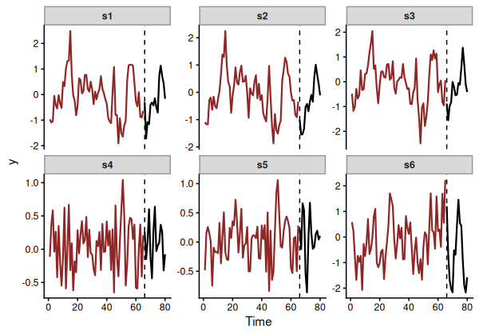

Six simulated series with the last 15 timepoints held out for forecast scoring. Series 1-3 track a long-memory trend, series 4-5 track a short-memory trend, and series 6 rides its own medium-memory trend with a larger amplitude.

```r
mvgam_data(train, y = "y", family = gaussian(), newdata = test)
```

## Fitting with a `trend_map`

We pass the sharing structure as a two-column `data.frame`. The `series` column lines up with the observed factor’s levels and the `trend` column carries the integer trend index; two rows pointing at the same integer share a latent path.

```r
tm_correct <- data.frame(
  series = paste0("s", seq_len(n_series)),
  trend = c(1L, 1L, 1L, 2L, 2L, 3L)
)
tm_correct
```

```
#>   series trend
#> 1     s1     1
#> 2     s2     1
#> 3     s3     1
#> 4     s4     2
#> 5     s5     2
#> 6     s6     3
```

The observation side is a single population intercept (`y ~ 1`); the trend side is an AR(1) process, applied to each of the three trends the `trend_map` implies. Passing `newdata = test` at fit time stores the test slice with the fitted object so later `forecast()` calls can use it without re-supplying.

```r
fit_correct <- mvgam(
  formula = y ~ 1,
  trend_formula = ~ AR(p = 1),
  trend_map = tm_correct,
  data = train,
  newdata = test,
  family = gaussian(),
  chains = 2L,
  samples = 500L,
  burnin = 500L,
  silent = 2L,
  refresh = 0
)
```

```r
summary(fit_correct)
```

```
#>  Family: gaussian
#>   Links: mu = identity
#> Formula: y ~ 1
#>    Data: <inline data> (Number of observations: 390)
#>  Series: 6
#>  Trends: AR(); formula: ~0
#>   Draws: 2 chains, each with iter = 500; warmup = 250; thin = 1;
#>          total post-warmup draws = 1000
#>
#> == Observation Model ==
#> Population-Level Effects:
#>           Estimate Est.Error l-95% CI u-95% CI Rhat Bulk_ESS Tail_ESS
#> Intercept     0.02      0.05    -0.08     0.11 1.01   260.04   384.97
#>
#> Further Distributional Parameters:
#>       Estimate Est.Error l-95% CI u-95% CI Rhat Bulk_ESS Tail_ESS
#> sigma      0.2      0.01     0.18     0.22 1.01   465.47   577.58
#>
#> == Trend Model ==
#> Trend Specific Parameters:
#>                Estimate Est.Error l-95% CI u-95% CI Rhat Bulk_ESS Tail_ESS
#> sigma_trend[1]     0.55      0.05     0.46     0.66 1.01   263.66   507.99
#> sigma_trend[2]     0.34      0.04     0.27     0.41 1.01   375.02   746.14
#> sigma_trend[3]     0.82      0.08     0.69     1.00 1.00   270.76   447.89
#> ar1_trend[1]       0.73      0.09     0.56     0.90 1.03   123.32   185.77
#> ar1_trend[2]       0.05      0.15    -0.24     0.35 1.01   251.05   486.41
#> ar1_trend[3]       0.44      0.13     0.17     0.67 1.02   105.56   222.80
#>
#> Draws were sampled using sampling(NUTS). For each parameter, Bulk_ESS
#> and Tail_ESS are effective sample size measures, and Rhat is the potential
#> scale reduction factor on split chains (at convergence, Rhat = 1).
#>
#> Next steps:
#>   - `pp_check(fit)`: posterior predictive checks
#>   - `forecast(fit, newdata = ...)`: out-of-sample forecasts
#>   - `loo(fit)` / `loo_compare(...)`: model fit + comparison
#> Use `how_to_cite(fit)` for a citation-ready model description.
```

## Recovering the latent trends

`hindcast(fit, type = "trend")` returns the latent-state posterior on its own scale, and `plot()` on that object renders one facet per series. Because we fixed series 1-3 to share trend 1, series 4-5 to share trend 2, and series 6 to ride trend 3, the panels within each sharing group carry identical draws:

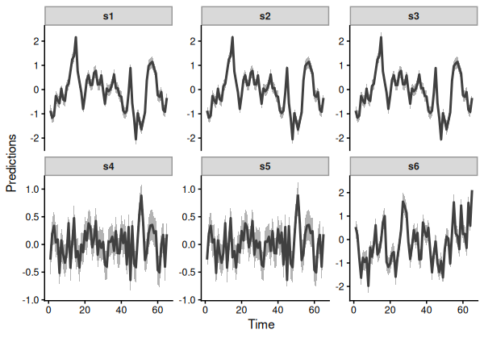

Trend-scale hindcasts. Series 1-3 (top row) share one latent path; series 4-5 (bottom left, centre) share another; series 6 (bottom right) rides its own trend.

```r
plot(hindcast(fit_correct, type = "trend"))
```

`plot(fit, type = "factors")` shows the latent processes directly, one panel per trend, annotated with the fraction of series-level variance each factor explains. Trend 1 dominates because three of the six series load on it; trend 2 contributes least; trend 3 sits in between with the outlier series’ larger-amplitude dynamics.

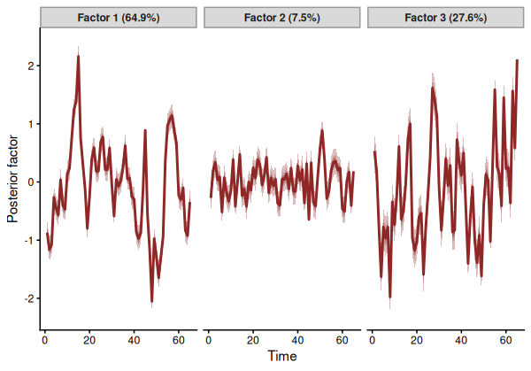

The three latent AR(1) factors recovered by the correct-loadings fit, with the percentage of series-level variance each explains. Trend 1 (three series) contributes most, trend 3 (the outlier series) contributes a substantial share, and trend 2 (two short-memory series) contributes least.

```r
plot(fit_correct, type = "factors")
```

## Forecasting on shared trends

The same projection carries into forecasts. The AR(1) recursion runs in latent space per posterior draw and the fixed $Z$ matrix maps each draw’s LV trajectory back to series scale. Series that share a trend receive the same latent forecast paths cell for cell, so the ribbons within each sharing group also match.

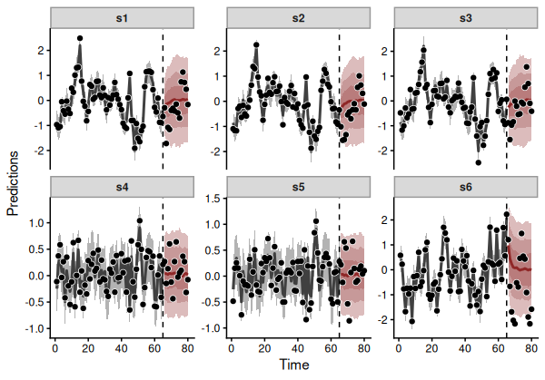

Forecasts under the correct trend_map. Series 1-3 reproduce the same latent forecast; series 4-5 do the same for the short-memory trend; series 6 forecasts its own dynamics. The long-memory ribbon fans out gradually; the short-memory ribbon returns to zero within a few timesteps.

```r
plot(forecast(fit_correct, newdata = test))
```

## Letting the model learn the loadings

Fixing the loadings is only the right call when domain knowledge tells you which series belong together. When the sharing structure is uncertain, hand the loadings to mvgam and let the sampler infer them. Passing an all-`NA` numeric matrix of the target size to `trend_map` tells mvgam to sample $Z$ under the default Student-t prior with the QR identification of Heaps & Jermyn ([2024](https://doi.org/10.1007/s11222-024-10454-0)).

```r
Z_free <- matrix(NA_real_, nrow = n_series, ncol = n_lv)
fit_free <- mvgam(
  formula = y ~ 1,
  trend_formula = ~ AR(p = 1),
  trend_map = Z_free,
  data = train,
  newdata = test,
  family = gaussian(),
  chains = 2L,
  samples = 500L,
  burnin = 500L,
  silent = 2L,
  refresh = 0
)
```

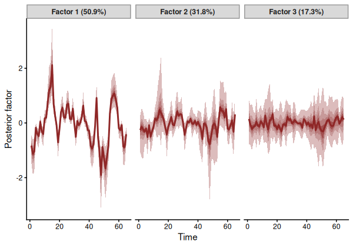

```r
plot(fit_free, type = "factors")
```

## When `trend_map` is wrong

`trend_map` is a hard prior on the sharing structure. Getting it wrong forces the model to explain distinct dynamics with a single latent path. To see how much that hurts, we fit a deliberately misspecified model that pools every series onto one shared trend (`trend_map = "shared"`) and compare its held-out forecast scores against the correct fit.

```r
fit_shared <- mvgam(
  formula = y ~ 1,
  trend_formula = ~ AR(p = 1),
  trend_map = "shared",
  data = train,
  newdata = test,
  family = gaussian(),
  chains = 2L,
  samples = 500L,
  burnin = 500L,
  silent = 2L,
  refresh = 0
)
```

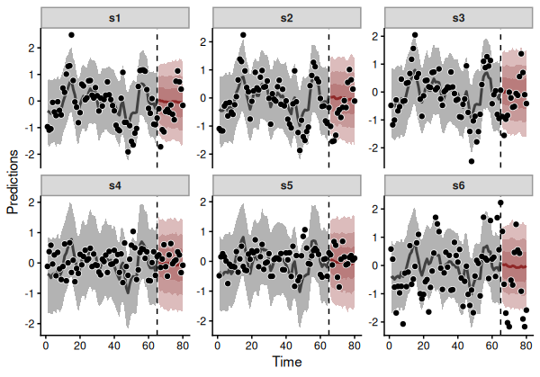

```r
plot(forecast(fit_shared, newdata = test))
```

`score()` quantifies the cost using strictly proper scoring rules. CRPS and the log score both penalise sharper forecasts less when they are close to the observation and more when they are far, so they measure both the mean and the calibration of the predictive distribution. Lower is better for both.

```r
score_totals <- function(fit) {
  fc <- forecast(fit, newdata = test)
  c(
    crps = sum(sapply(
      score(fc, score = "crps")[levels(train$series)],
      function(x) sum(x$score, na.rm = TRUE)
    )),
    logs = sum(sapply(
      score(fc, score = "logs")[levels(train$series)],
      function(x) sum(x$score, na.rm = TRUE)
    )),
    energy = sum(score(fc, score = "energy")$all_series$score,
                  na.rm = TRUE)
  )
}
scores_tbl <- rbind(
  correct = score_totals(fit_correct),
  shared  = score_totals(fit_shared),
  free    = score_totals(fit_free)
)
round(scores_tbl, 2)
```

```
#>          crps   logs energy
#> correct 38.16  93.63  19.52
#> shared  41.16 110.80  20.39
#> free    41.74 105.29  21.27
```

The practical takeaway is that a held-out forecast score is a useful diagnostic on the sharing structure itself. When two plausible `trend_map` specifications disagree, fitting both and comparing `score()` outputs on a real test slice tells you which sharing pattern the data actually support.

## Take-aways

A dynamic factor model in mvgam is a state-space fit where fewer latent processes drive more observed series. `trend_map` supplies the sharing structure. The accepted input shapes range from the `"identity"` and `"shared"` character shorthands through a `data.frame` of named sharing groups to a numeric matrix that handles the general case with optional partial-Z entries. Downstream methods work unchanged. The parameter catalogue only grows by the per-trend scalars belonging to whatever trend model was supplied.

When the sharing structure is known, fixing it via `trend_map` gives the tightest and best-calibrated forecasts. When the structure is uncertain, an all-`NA` matrix lets mvgam learn the loadings jointly with the trend parameters, recovering the same underlying latent shapes at a moderate score cost from the extra identification uncertainty. When two candidate structures disagree, fitting both and comparing `score()` outputs on a held-out slice is a practical way to let the data decide.

Reach for `how_to_cite(fit)` when you want a citation-ready methods paragraph naming the trend, family and sampler configuration used on the fit. For the same content rendered as Markdown plus LaTeX for a manuscript methods section, `methods_md(fit)` produces a paste-ready block.

## Further reading

The natural next functions to explore on the same fit are:

- `?mvgam` for the full fitter signature, including the sibling `loadings_prior` argument that adds a structured prior to the sampled entries of $Z$ when using the numeric matrix form.
- `?hindcast.mvgam` and `?forecast.mvgam` for the prediction surface, including the `type = "trend"` view used above.
- `?score` for the strictly proper scoring rules used to compare forecast performance in this vignette.
- `?ensemble` and `?lfo_cv` for the two forecast-comparison workhorses built on top of `score`.
- `?jsdgam` for the joint species distribution wrapper, which uses the same partial-Z path to identify a factor model on multispecies count or occurrence data.
- `?mcmc_plot` for parameter posterior visualisation on any variable reported by `variables(fit)`.

Sibling articles in this series carry the workflow further:

- The [forecast evaluation article](https://nicholasjclark.github.io/mvgam/articles/forecast_evaluation.html) walks through `forecast()`, `score()`, `lfo_cv()` and `ensemble()` on a worked example with count observations.
- The [multi-response article](https://nicholasjclark.github.io/mvgam/articles/mvbf.html) covers the different case where several outcomes on different observation families share a single latent trend via a multivariate observation formula.
- The [JSDM article](https://nicholasjclark.github.io/mvgam/articles/jsdgam.html) applies the factor-model architecture to community ecology data with informed loadings.

## Acknowledgements

The dynamic factor model on which `trend_map` is built follows Zuur et al. ([2003](https://doi.org/10.1002/env.611)); the MARSS R package (Holmes et al. [2012](https://doi.org/10.32614/RJ-2012-002)) is the reference implementation the syntax deliberately echoes. The identification approach for factor models follows Heaps & Jermyn ([2024](https://doi.org/10.1007/s11222-024-10454-0)); mvgam applies a QR rotation in generated quantities to identify factor models with free loadings, and skips this rotation whenever a user supplies a `trend_map`. Formulas rely on mgcv smooths (Wood [2017](https://doi.org/10.1201/9781315370279)) and brms’s multilevel apparatus (Bürkner [2017](https://doi.org/10.18637/jss.v080.i01)); the dynamic generalised additive model framing follows Clark & Wells ([2023](https://doi.org/10.1111/2041-210X.13974)); sampling is performed with Stan (Carpenter et al. [2017](https://doi.org/10.18637/jss.v076.i01)).

## References

Bürkner, P.-C. (2017). brms: An R package for Bayesian multilevel models using Stan. *Journal of Statistical Software* 80(1), 1-28. [doi:10.18637/jss.v080.i01](https://doi.org/10.18637/jss.v080.i01)

Carpenter, B., Gelman, A., Hoffman, M. D., Lee, D., Goodrich, B., Betancourt, M., Brubaker, M., Guo, J., Li, P. and Riddell, A. (2017). Stan: A probabilistic programming language. *Journal of Statistical Software* 76(1), 1-32. [doi:10.18637/jss.v076.i01](https://doi.org/10.18637/jss.v076.i01)

Clark, N. J. and Wells, K. (2023). Dynamic Generalized Additive Models (DGAMs) for forecasting discrete ecological time series. *Methods in Ecology and Evolution* 14, 771-784. [doi:10.1111/2041-210X.13974](https://doi.org/10.1111/2041-210X.13974)

Heaps, S. E. and Jermyn, I. H. (2024). Structured prior distributions for the covariance matrix in latent factor models. *Statistics and Computing* 34, 143. [doi:10.1007/s11222-024-10454-0](https://doi.org/10.1007/s11222-024-10454-0)

Holmes, E. E., Ward, E. J. and Wills, K. (2012). MARSS: Multivariate Autoregressive State-space Models for Analyzing Time-series Data. *The R Journal* 4(1), 11-19. [doi:10.32614/RJ-2012-002](https://doi.org/10.32614/RJ-2012-002)

Wood, S. N. (2017). *Generalized Additive Models: An Introduction with R* (2nd edition). Chapman and Hall/CRC. [doi:10.1201/9781315370279](https://doi.org/10.1201/9781315370279)

Zuur, A. F., Fryer, R. J., Jolliffe, I. T., Dekker, R. and Beukema, J. J. (2003). Estimating common trends in multivariate time series using dynamic factor analysis. *Environmetrics* 14(7), 665-685. [doi:10.1002/env.611](https://doi.org/10.1002/env.611)